# Autoencoder & GANs

Shan-Hung Wu & DataLab  
Fall 2017

In this lab, we are going to introduce two types of unsupervised learning model: Autoencoder and Generative Adversarial Networks (GANs)

# Autoencoder

Autoencoder is a popular unsupervised learning model, which is used to reduce data dimension or used in some end2end learning model, like img2img translation. Autoencoder has two compoments encoder and decoder. Encoder learns a code representation c of input data, and decoder learns to reconstruct input data from c. As we have the pretrained encoder we can reduce the data dimension to the code size. Note that since this is a neural network model, it is much more efficient than other data dimension reduction methods.

[figure not shown]

```python
# Import libraries
import sys
import os
os.environ["CUDA_VISIBLE_DEVICES"] = '3'
import numpy as np
%matplotlib inline
import matplotlib.pyplot as plt
from time import time
import tensorflow as tf
from tensorflow.contrib import learn
from tqdm import trange
from time import time
from Autoencoder.utils import *
```

We demo the autoencoder by MNIST dataset. In the following, we will show our setting of model initializer, the reconstruction results and the manifold learning performance(which can be compared to denoising autoencoder latter).

Note: In MNIST dataset, although the pixels are ranged in [0,1], we recommand to use binary cross entropy loss to have sharper reconstructed results.

Some setting is referenced from [The Keras Blog: Autoencoder](https://blog.keras.io/building-autoencoders-in-keras.html)

```python
class AutoEncoder(object):

  def __init__(self,
               sess,
               inputs,
               targets=None,
               b1=0.5,
               lr=1.,
               code_size=16,
               batch_size=256,
               n_epoch=200,
               cost_function='bce',
               name='autoencoder',
               optimizer='adadelta'):
    self.sess = sess  #tensorflow session
    self.b1 = b1  #beta1 for AdadeltaOptimizer
    self.lr = lr  #learning rate
    self.n_epoch = n_epoch  #number of epoch
    self.batch_size = batch_size
    self.inputs = inputs
    self.code_size = code_size  #embedding size
    self.load_dataset()
    if targets is not None:
      self.targets = targets  #for autoencoder, targets is the same to input
      self.gen_noisy_data()
    else:
      self.targets = inputs
    self.cost_function = cost_function
    self.optimizer = optimizer
    self.log = {'train_loss': [], 'valid_loss': []}

    self.name = name

    self.build_model()

  def build_model(self):
    code_size = self.code_size
    with tf.variable_scope(self.name) as scope:
      self.enc1 = tf.layers.dense(
          inputs=self.inputs,
          units=code_size * 16,
          activation=tf.nn.relu,
          name='enc')
      self.enc2 = tf.layers.dense(
          inputs=self.enc1,
          units=code_size * 8,
          activation=tf.nn.relu,
          name='enc2')
      self.enc3 = tf.layers.dense(
          inputs=self.enc2,
          units=code_size * 4,
          activation=tf.nn.relu,
          name='enc3')
      self.code = tf.layers.dense(
          inputs=self.enc3, units=code_size, activation=tf.nn.relu, name='code')

      self.dec1 = tf.layers.dense(
          inputs=self.code,
          units=code_size * 4,
          activation=tf.nn.relu,
          name='dec')
      self.dec2 = tf.layers.dense(
          inputs=self.dec1,
          units=code_size * 8,
          activation=tf.nn.relu,
          name='dec2')
      self.dec3 = tf.layers.dense(
          inputs=self.dec2,
          units=code_size * 16,
          activation=tf.nn.relu,
          name='dec3')
      self.recon_logits = tf.layers.dense(
          inputs=self.dec3, units=28 * 28, name='recon_logits')
      self.jacobian_op = self.jacobian(self.code, self.inputs)
      if self.cost_function == 'mse':
        self.recon = self.recon_logits
        self.cost = tf.reduce_mean(tf.pow(self.targets - self.recon_logits, 2))
      elif self.cost_function == 'bce':
        self.recon = tf.nn.sigmoid(self.recon_logits)
        self.cost = tf.reduce_mean(
            tf.nn.sigmoid_cross_entropy_with_logits(
                labels=self.targets, logits=self.recon_logits))

      else:
        raise NotImplementedError

  def train(self):
    if self.optimizer == 'adadelta':
      self.optim = tf.train.AdadeltaOptimizer(self.lr).minimize(self.cost)
    elif self.optimizer == 'adam':
      self.optim = tf.train.AdamOptimizer(
          self.lr, beta1=self.b1).minimize(self.cost)
    elif self.optimizer == 'rmsprop':
      self.optim = tf.train.RMSPropOptimizer(self.lr).minimize(self.cost)
    else:
      raise NotImplementedError
    init = tf.global_variables_initializer()
    self.sess.run(init)

    X = self.inputs
    t0 = time()
    if self.targets is not self.inputs:
      print('Denoising autoencoder')
      Y = self.targets
      for epoch in trange(self.n_epoch):
        t = time()
        shuffle(self.trX, self.trX_noisy)
        for batch, noisy_batch in iter_data(
            self.trX, self.trX_noisy, size=self.batch_size):
          self.optim.run(
              session=self.sess, feed_dict={X: noisy_batch,
                                            Y: batch})

        idxs = np.random.randint(
            low=0, high=len(self.vaX), size=self.batch_size)
        valid_batch = self.vaX[idxs]
        valid_noisy_batch = self.vaX_noisy[idxs]

        self.log['train_loss'].append(
            self.cost.eval(
                session=self.sess, feed_dict={X: noisy_batch,
                                              Y: batch}))
        self.log['valid_loss'].append(
            self.cost.eval(
                session=self.sess,
                feed_dict={X: valid_noisy_batch,
                           Y: valid_batch}))
      print("final loss %g, total cost time: %.2fs" % (self.cost.eval(
          session=self.sess, feed_dict={X: self.teX_noisy,
                                        Y: self.teX}), time() - t0))

    else:
      print('Audoencoder')
      for epoch in trange(self.n_epoch):
        t = time()
        shuffle(self.trX)
        for batch in iter_data(self.trX, size=self.batch_size):
          self.optim.run(session=self.sess, feed_dict={X: batch})

        idxs = np.random.randint(
            low=0, high=len(self.vaX), size=self.batch_size)
        valid_batch = self.vaX[idxs]

        self.log['train_loss'].append(
            self.cost.eval(session=self.sess, feed_dict={X: batch}))
        self.log['valid_loss'].append(
            self.cost.eval(session=self.sess, feed_dict={X: valid_batch}))
      print("final loss %g, total cost time: %.2fs" %
            (self.cost.eval(session=self.sess, feed_dict={X: self.teX}),
             time() - t0))

  def load_dataset(self):
    mnist = learn.datasets.load_dataset("mnist")
    self.trX = mnist.train.images  # Returns np.array
    self.vaX = mnist.validation.images  # Returns np.array
    self.teX = mnist.test.images

  def gen_noisy_data(self):
    # Noise scale
    noise_factor = 0.4
    trX_noisy = self.trX + noise_factor * np.random.normal(
        loc=0., scale=1.0, size=self.trX.shape)
    vaX_noisy = self.vaX + noise_factor * np.random.normal(
        loc=0., scale=1.0, size=self.vaX.shape)
    teX_noisy = self.teX + noise_factor * np.random.normal(
        loc=0., scale=1.0, size=self.teX.shape)

    # Range of our dataset is [0,1]
    self.trX_noisy = np.clip(trX_noisy, 0., 1.)
    self.vaX_noisy = np.clip(vaX_noisy, 0., 1.)
    self.teX_noisy = np.clip(teX_noisy, 0., 1.)

  def encode(self, inputs):

    return self.code.eval(session=self.sess, feed_dict={self.inputs: inputs})

  def reconstruct(self, inputs):
    return self.recon.eval(session=self.sess, feed_dict={self.inputs: inputs})

  def jacobian(self, y, x):
    # For function f: mapping from single column x to multiple values ys
    # Note: tf.gradients returns sum(dy/dx)
    # for each x in xs, so we need to compute each y seperatedly.
    jacobian_flat = tf.concat(
        [tf.gradients(y_i, x)[0] for y_i in tf.unstack(y, axis=1)], axis=0)
    return jacobian_flat

  def get_jaco_matrix(self, xbatch):
    jaco_matrix = []
    for x in xbatch:
      jaco_matrix.append(
          self.jacobian_op.eval(
              session=self.sess, feed_dict={self.inputs: x.reshape(1, -1)})
          .reshape(1, self.code_size, 28 * 28))
    return np.concatenate(jaco_matrix)
```

```python
sess = tf.Session()
X = tf.placeholder(tf.float32, shape=[None, 28 * 28])
autoencoder = AutoEncoder(sess=sess, inputs=X, optimizer='adadelta', lr=1)
autoencoder.train()
```

```
Extracting MNIST-data/train-images-idx3-ubyte.gz
Extracting MNIST-data/train-labels-idx1-ubyte.gz
Extracting MNIST-data/t10k-images-idx3-ubyte.gz
Extracting MNIST-data/t10k-labels-idx1-ubyte.gz
```

```
Audoencoder
```

```
final loss 0.102375, total cost time: 388.04s
```

Plot the learning curve to check if the training is converged.

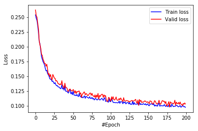

```python
train_loss = autoencoder.log['train_loss']
valid_loss = autoencoder.log['valid_loss']
plt.plot(range(len(train_loss)), train_loss, color='blue', label='Train loss')
plt.plot(range(len(valid_loss)), valid_loss, color='red', label='Valid loss')
plt.legend(loc="upper right")
plt.xlabel('#Epoch')
plt.ylabel('Loss')
plt.show()
```

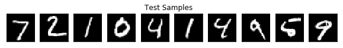

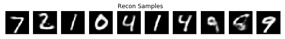

```python
n = 10

orig_imgs = autoencoder.teX[:n].reshape(-1, 28, 28)
recon_imgs = autoencoder.reconstruct(
  orig_imgs.reshape(-1, 28 * 28)).reshape(-1, 28, 28)

plot_imgs(orig_imgs, n=n, title='Test Samples')
plot_imgs(recon_imgs, n=n, title='Recon Samples')
```

### Tangent vectors & Jacobian matrix

Autoencoder can also learn manifold. To justify this, we can plot the tangent vectors.

Extract tangent vectors:

1. Sample a data $x_0$
2. Compute Jacobian matrix $J(x_0)$ of $f: Image \mapsto Code$
3. Compute SVD of $J(x_0)$, $J(x_0) = U\Sigma V^T$
4. Pick top K eigenvectors from V as tangent vectors.

In the following demo, we use the first sample in testing data, which is a digit 7 image.

```
(1, 16, 784)
(16,)
```

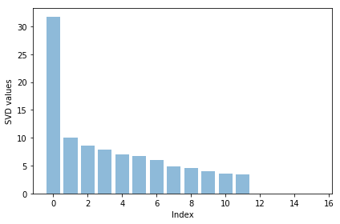

```
(16, 784)
```

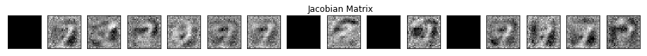

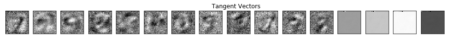

```python
img = autoencoder.teX[:1]
jaco_matrix = autoencoder.get_jaco_matrix(img)
print(jaco_matrix.shape)
V = tangent_vecs(jaco_matrix[0])
print(V.shape)
plot_imgs(jaco_matrix.reshape(-1, 28, 28), n=16, title='Jacobian Matrix')
plot_imgs(V.reshape(-1, 28, 28), n=16, title='Tangent Vectors')
```

# Denoising Autoencoder and Manifold Learning

As the above result, autoencoder can learn manifold. However, it's not good enough. We can improve it by adding regularization term for Jacobian matrix of reconstruction or simply adding noise to data, to make the codes more robust to input images. You can find more details from this [paper](https://www.iro.umontreal.ca/~vincentp/Publications/denoising_autoencoders_tr1316.pdf).

[figure not shown]

Given appropriate noisy magnitude, denoising autoencoder can learn the direction toward the data manifold, mapping noisy data to original one.

```python
sess.close()
tf.reset_default_graph()
sess = tf.Session()
X = tf.placeholder(tf.float32, shape=[None, 28 * 28])
Y = tf.placeholder(tf.float32, shape=[None, 28 * 28])

# In our AutoEncoder class,
# it will automatically change to denoising autoencoder if "targets" is given.
autoencoder = AutoEncoder(
    sess=sess, inputs=X, targets=Y, optimizer='adadelta', lr=1)
# autoencoderModel = AutoEncoder(
#     sess=sess, inputs=X, optimizer='adam', niter=200, cost_function='mse')
autoencoder.train()
```

```
Extracting MNIST-data/train-images-idx3-ubyte.gz
Extracting MNIST-data/train-labels-idx1-ubyte.gz
Extracting MNIST-data/t10k-images-idx3-ubyte.gz
Extracting MNIST-data/t10k-labels-idx1-ubyte.gz
```

```
Denoising autoencoder
```

```
final loss 0.116553, total cost time: 713.80s
```

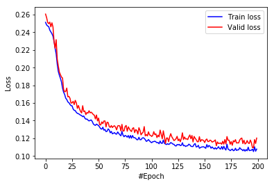

```python
train_loss = autoencoder.log['train_loss']
valid_loss = autoencoder.log['valid_loss']
plt.plot(range(len(train_loss)), train_loss, color='blue', label='Train loss')
plt.plot(range(len(valid_loss)), valid_loss, color='red', label='Valid loss')
plt.legend(loc="upper right")
plt.xlabel('#Epoch')
plt.ylabel('Loss')
plt.show()
```

The reconstruction results here, compared to the above ones, are little more blurry but we can still distinguish each different digits.

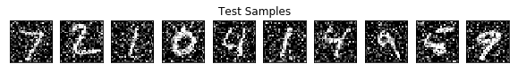

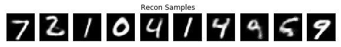

```python
n = 10

orig_imgs = autoencoder.teX_noisy[:n].reshape(-1, 28, 28)
recon_imgs = autoencoder.reconstruct(
  orig_imgs.reshape(-1, 28 * 28)).reshape(-1, 28, 28)

plot_imgs(orig_imgs, n=n, title='Test Samples')
plot_imgs(recon_imgs, n=n, title='Recon Samples')
```

Plot the Jacobian matrix and tangent vectors given a single digit 7 image.

```
(16,)
```

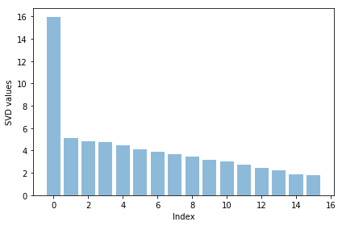

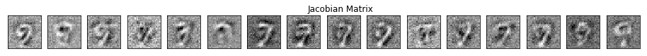

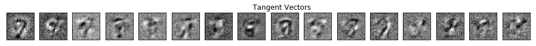

```python
img = autoencoder.teX[:1]
jaco_matrix = autoencoder.get_jaco_matrix(img)
V = tangent_vecs(jaco_matrix[0])
plot_imgs(jaco_matrix.reshape(-1, 28, 28), n=16, title='Jacobian Matrix')
plot_imgs(V.reshape(-1, 28, 28), n=16, title='Tangent Vectors')

#reset the system path
sys.path.pop()

#reset tensorflow graph
tf.reset_default_graph()
sess.close()
```

As the result, we can see that the tangent vectors are more sharper.

# DCGAN

[Generative adversarial networks(GANs)](https://papers.nips.cc/paper/5423-generative-adversarial-nets.pdf) is a generative model proposed by Ian Goodfellow etc. in 2014.

[figure not shown]

[figure not shown]

In this lab, we modified the code from [DCGAN in tensorflow](https://github.com/carpedm20/DCGAN-tensorflow) and [original DCGAN in theano](https://github.com/Newmu/dcgan_code). We demo the training of DCGAN on MNIST dataset.

[figure not shown]

Some notes in DCGAN (referenced from [paper](https://arxiv.org/pdf/1511.06434.pdf)):

- Replace any pooling layers with strided convolutions (discriminator) and fractional-strided convolutions (generator).
  - Each convolutional layer halved the feature maps resolution. (Not hard requirement.)
- Use batchnorm in both the generator and the discriminator.
  - The batchnorm here is the simplest one just normalize the feature activations.
  - Don't use batchnorm in the last few layers in generator. Since it may make it difficult for generator to fit the variance of real data. For example, if the mean of data is not zero, and we use batchnorm and Tanh in the last layer of G, then it will never match the true data distribution.
- Use ReLU activation in generator for all layers except for the output, which uses Tanh or Sigmoid.
  - Tanh or Sigmoid depends on the range of real data.
- Use LeakyReLU activation in the discriminator for all layers.
  - LeakyReLu is recommened by AllConvNet approach for faster training.

In the following code, we

1. specify the checkpoint directory to store the model snapshots and samples directory to store generated samples
2. initialize DCGAN in dcgan.py and train on the default dataset, MNIST.(Change dataset need to modify code in dcgan.py)

```python
import sys
sys.path.append('GAN')
from GAN.utils import *
from GAN.ops import *

import os
%matplotlib inline
import matplotlib.pyplot as plt
import numpy as np
import tensorflow as tf
import time
import math
from glob import glob
from tensorflow.contrib import learn
import numpy as np
from tqdm import tqdm
```

```python
class DCGAN(object):

  def __init__(self,
               sess,
               input_height=28,
               input_width=28,
               crop=True,
               batch_size=128,
               output_height=28,
               output_width=28,
               y_dim=None,
               z_dim=100,
               gf_dim=64,
               df_dim=64,
               gfc_dim=1024,
               dfc_dim=1024,
               c_dim=1,
               dataset_name='mnist',
               input_fname_pattern='*.jpg',
               checkpoint_dir='checkpoint',
               samples_dir=None,
               show_samples=False,
               learning_rate=2e-4,
               beta1=0.5,
               epoch=100):
    """
    Args:
      sess: TensorFlow session
      batch_size: The size of batch. Should be specified before training.
      y_dim: (optional) Dimension of dim for y. [None]
      z_dim: (optional) Dimension of dim for Z. [100]
      gf_dim: (optional) Dimension of gen filters in first conv layer. [64]
      df_dim: (optional) Dimension of discrim filters in first conv layer. [64]
      gfc_dim: (optional) Dimension of gen units for for fully connected layer. [1024]
      dfc_dim: (optional) Dimension of discrim units for fully connected layer. [1024]
      c_dim: (optional) Dimension of image color. For grayscale input, set to 1. [3]
        """
    self.sess = sess

    self.epoch = epoch
    self.batch_size = batch_size
    self.sample_num = 200
    self.learning_rate = learning_rate
    self.beta1 = beta1

    self.input_height = input_height
    self.input_width = input_width
    self.output_height = output_height
    self.output_width = output_width

    self.y_dim = y_dim
    self.z_dim = z_dim

    self.gf_dim = gf_dim
    self.df_dim = df_dim

    self.gfc_dim = gfc_dim
    self.dfc_dim = dfc_dim

    self.input_fname_pattern = input_fname_pattern
    self.dataset_name = dataset_name
    self.checkpoint_dir = checkpoint_dir
    if not os.path.exists(checkpoint_dir):
      os.makedirs(checkpoint_dir)

    self.samples_dir = samples_dir
    if not os.path.exists(samples_dir) and samples_dir is not None:
      os.makedirs(samples_dir)
    self.show_samples = show_samples

    self.trX, self.teX = self.load_mnist()
    self.ntrain = len(self.trX)
    self.c_dim = 1
    self.grayscale = (self.c_dim == 1)
    self.log = {'d_loss': [], 'g_loss': [], 'gen_samples': []}
    self.build_model()

  def build_model(self):
    image_dims = [self.input_height, self.input_width, self.c_dim]

    self.inputs = tf.placeholder(
        tf.float32, [None] + image_dims, name='real_images')
    self.sample_inputs = tf.placeholder(
        tf.float32, [None] + image_dims, name='sample_inputs')

    inputs = self.inputs
    sample_inputs = self.sample_inputs

    self.z = tf.placeholder(tf.float32, [None, self.z_dim], name='z')

    self.G = self.generator(self.z)
    self.D, self.D_logits_real = self.discriminator(inputs)

    self.D_, self.D_logits_fake = self.discriminator(self.G, reuse=True)

    self.d_loss_real = tf.reduce_mean(
        bce(self.D_logits_real, tf.ones_like(self.D)))
    self.d_loss_fake = tf.reduce_mean(
        bce(self.D_logits_fake, tf.zeros_like(self.D_)))
    self.g_loss = tf.reduce_mean(bce(self.D_logits_fake, tf.ones_like(self.D_)))

    self.d_loss = self.d_loss_real + self.d_loss_fake

    t_vars = tf.trainable_variables()
    # get variables for generator and discriminator,
    # since they are trained separately.
    self.d_vars = [var for var in t_vars if 'd_' in var.name]
    self.g_vars = [var for var in t_vars if 'g_' in var.name]

    self.saver = tf.train.Saver()

  def train(self):
    #get the optimization ops
    d_optim = tf.train.AdamOptimizer(self.learning_rate, beta1=self.beta1) \
              .minimize(self.d_loss, var_list=self.d_vars)
    g_optim = tf.train.AdamOptimizer(self.learning_rate, beta1=self.beta1) \
              .minimize(self.g_loss, var_list=self.g_vars)
    init = tf.global_variables_initializer()
    self.sess.run(init)

    #generate random noise
    sample_z = np.random.uniform(-1, 1, size=(self.sample_num, self.z_dim))
    sample_idxs = np.random.randint(
        low=0, high=len(self.trX), size=self.sample_num)
    sample_inputs = self.trX[sample_idxs]

    counter = 1
    start_time = time.time()
    print('start training')
    for epoch in range(self.epoch):
      shuffle(self.trX)
      for batch_images in iter_data(self.trX, size=self.batch_size):
        batch_z = np.random.uniform(-1, 1, [self.batch_size,
                                            self.z_dim]).astype(np.float32)
        if counter % 2 == 0:
          # Update D network
          self.sess.run(
              d_optim, feed_dict={
                  self.inputs: batch_images,
                  self.z: batch_z,
              })
        else:
          # Update G network
          self.sess.run(
              g_optim, feed_dict={
                  self.z: batch_z,
              })
        counter += 1

      # calculate the loss to monitor the training process
      errD_fake = self.d_loss_fake.eval(
          session=self.sess, feed_dict={self.z: batch_z})
      errD_real = self.d_loss_real.eval(
          session=self.sess, feed_dict={self.inputs: batch_images})
      errG = self.g_loss.eval(session=self.sess, feed_dict={self.z: batch_z})
      self.log['d_loss'].append(errD_fake + errD_real)
      self.log['g_loss'].append(errG)
      print("Epoch: [%2d] time: %.2fs, d_loss: %.4f, g_loss: %.4f" \
        % (epoch,time.time() - start_time, errD_fake+errD_real, errG))

      # save the generated samples
      if (epoch + 1) % 1 == 0:
        samples = self.sess.run(
            self.G, feed_dict={
                self.z: sample_z,
            })
        img = grayscale_grid_vis(
            samples,
            nhw=(10, 20),
            save_path=self.samples_dir + '/%d.jpg' % epoch)
        self.log['gen_samples'].append(img)
        if (epoch + 1) % 10 == 0:
          if self.show_samples:
            plt.imshow(img, cmap='gray')
            plt.axis('off')
            plt.show()

      if (epoch + 1) % 10 == 0:
        self.save(self.checkpoint_dir, counter)

  def discriminator(self, image, y=None, reuse=False):
    with tf.variable_scope("discriminator") as scope:
      if reuse:
        scope.reuse_variables()

      x = image

      h0 = lrelu(conv2d(x, self.c_dim, name='d_h0_conv'))
      h1 = lrelu(bn(conv2d(h0, self.df_dim, name='d_h1_conv')))
      h1 = flatten(h1)
      h2 = lrelu(bn(linear(h1, self.dfc_dim, 'd_h2_lin')))
      h3 = linear(h2, 1, 'd_h3_lin')

      return tf.nn.sigmoid(h3), h3

  def generator(self, z, y=None):
    with tf.variable_scope("generator") as scope:
      s_h, s_w = self.output_height, self.output_width
      s_h2, s_h4 = int(s_h / 2), int(s_h / 4)
      s_w2, s_w4 = int(s_w / 2), int(s_w / 4)

      h0 = tf.nn.relu(bn(linear(z, self.gfc_dim, 'g_h0_lin')))

      h1 = tf.nn.relu(bn(linear(h0, self.gf_dim * 2 * s_h4 * s_w4, 'g_h1_lin')))
      h1 = tf.reshape(h1, [-1, s_h4, s_w4, self.gf_dim * 2])

      h2 = tf.nn.relu(bn(deconv2d(h1, nf=self.gf_dim * 2, name='g_h2')))
      return tf.nn.sigmoid(deconv2d(h2, nf=self.c_dim, name='g_h3'))

  def load_mnist(self):
    mnist = learn.datasets.load_dataset("mnist")
    train_data = mnist.train.images.reshape(-1, 28, 28, 1)  # Returns np.array
    test_data = mnist.test.images.reshape(-1, 28, 28, 1)  # Returns np.array
    return train_data, test_data

  @property
  def model_dir(self):
    return "%s_%s" % (self.dataset_name, self.batch_size)

  def save(self, checkpoint_dir, step):
    model_name = "DCGAN.model"
    checkpoint_dir = os.path.join(checkpoint_dir, self.model_dir)

    if not os.path.exists(checkpoint_dir):
      os.makedirs(checkpoint_dir)

    self.saver.save(
        self.sess, os.path.join(checkpoint_dir, model_name), global_step=step)

  def load(self, checkpoint_dir):
    import re
    print(" [*] Reading checkpoints...")
    checkpoint_dir = os.path.join(checkpoint_dir, self.model_dir)

    ckpt = tf.train.get_checkpoint_state(checkpoint_dir)
    if ckpt and ckpt.model_checkpoint_path:
      ckpt_name = os.path.basename(ckpt.model_checkpoint_path)
      self.saver.restore(self.sess, os.path.join(checkpoint_dir, ckpt_name))
      counter = int(next(re.finditer("(\d+)(?!.*\d)", ckpt_name)).group(0))
      print(" [*] Success to read {}".format(ckpt_name))
      return True, counter
    else:
      print(" [*] Failed to find a checkpoint")
      return False, 0
```

```python
# Specifiy model checkpoint directory & samples directory
checkpoint_dir = 'checkpoint'
samples_dir = 'samples'

tf.reset_default_graph()

sess = tf.Session()
dcgan = DCGAN(
    sess,
    input_width=28,
    input_height=28,
    output_width=28,
    output_height=28,
    batch_size=128,
    input_fname_pattern='*.jpg',
    checkpoint_dir=checkpoint_dir,
    samples_dir=samples_dir,
    show_samples=True,
    epoch=100)
```

```
Extracting MNIST-data/train-images-idx3-ubyte.gz
Extracting MNIST-data/train-labels-idx1-ubyte.gz
Extracting MNIST-data/t10k-images-idx3-ubyte.gz
Extracting MNIST-data/t10k-labels-idx1-ubyte.gz
```

Let's plot the generated images right after the initialization. It's good to check if there are any unexpacted artifacts in it. For case of DCGAN, we should see checkboard effect in our generated samples if we use fully convolutional layers. As mentioned in this [blog post](http://distill.pub/2016/deconv-checkerboard/), this will introduce some checkboard effect. If the training is succeed, then this effect can be largely reduced. The blog post used upsampling to replace strided deconvolution in generator. This can cancell off the checkboard effect but have more blury result.

In the following cell, we also plot the original MNIST dataset.

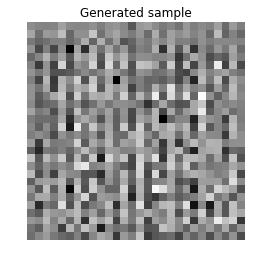

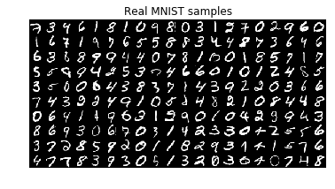

```python
init = tf.global_variables_initializer()
sess.run(init)
sample_z = np.random.uniform(-1, 1, size=(200, 100))
samples = dcgan.G.eval(session=dcgan.sess, feed_dict={dcgan.z: sample_z})
plt.imshow(samples[0].reshape(28, 28), cmap='gray')
plt.axis('off')
plt.title('Generated sample')
plt.show()

samples = dcgan.trX[:200]
img = grayscale_grid_vis(samples, nhw=(10, 20))
plt.imshow(img, cmap='gray')
plt.axis('off')
plt.title('Real MNIST samples')
plt.show()
```

```
start training
Epoch: [ 0] time: 9.47s, d_loss: 0.6706, g_loss: 1.3559
Epoch: [ 1] time: 18.51s, d_loss: 1.0176, g_loss: 0.9393
Epoch: [ 2] time: 27.61s, d_loss: 1.1929, g_loss: 0.8304
Epoch: [ 3] time: 36.70s, d_loss: 1.1571, g_loss: 0.8426
Epoch: [ 4] time: 45.81s, d_loss: 1.2032, g_loss: 0.8374
Epoch: [ 5] time: 54.93s, d_loss: 1.1704, g_loss: 0.8626
Epoch: [ 6] time: 64.01s, d_loss: 1.2318, g_loss: 0.8516
Epoch: [ 7] time: 73.12s, d_loss: 1.2385, g_loss: 0.8365
Epoch: [ 8] time: 82.15s, d_loss: 1.2391, g_loss: 0.8353
Epoch: [ 9] time: 91.24s, d_loss: 1.2840, g_loss: 0.8369
```

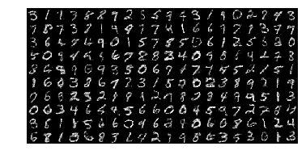

```
Epoch: [10] time: 101.96s, d_loss: 1.2423, g_loss: 0.8018
Epoch: [11] time: 111.06s, d_loss: 1.2172, g_loss: 0.8040
Epoch: [12] time: 120.16s, d_loss: 1.2477, g_loss: 0.8039
Epoch: [13] time: 129.31s, d_loss: 1.2316, g_loss: 0.7940
Epoch: [14] time: 138.27s, d_loss: 1.2322, g_loss: 0.8305
Epoch: [15] time: 147.37s, d_loss: 1.2137, g_loss: 0.8151
Epoch: [16] time: 156.48s, d_loss: 1.2460, g_loss: 0.8013
Epoch: [17] time: 165.54s, d_loss: 1.2664, g_loss: 0.8273
Epoch: [18] time: 174.71s, d_loss: 1.2334, g_loss: 0.7895
Epoch: [19] time: 183.78s, d_loss: 1.2216, g_loss: 0.8038
```

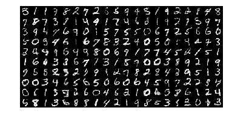

```
Epoch: [20] time: 194.30s, d_loss: 1.2682, g_loss: 0.8005
Epoch: [21] time: 203.35s, d_loss: 1.2580, g_loss: 0.7838
Epoch: [22] time: 212.41s, d_loss: 1.3198, g_loss: 0.8269
Epoch: [23] time: 221.55s, d_loss: 1.2540, g_loss: 0.8058
Epoch: [24] time: 230.62s, d_loss: 1.2398, g_loss: 0.8087
Epoch: [25] time: 239.61s, d_loss: 1.2909, g_loss: 0.8325
Epoch: [26] time: 248.81s, d_loss: 1.2248, g_loss: 0.8201
Epoch: [27] time: 257.87s, d_loss: 1.2530, g_loss: 0.7926
Epoch: [28] time: 266.93s, d_loss: 1.2333, g_loss: 0.8362
Epoch: [29] time: 276.04s, d_loss: 1.2286, g_loss: 0.8060
```

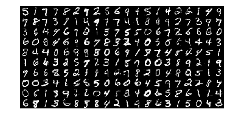

```
Epoch: [30] time: 285.93s, d_loss: 1.2737, g_loss: 0.8328
Epoch: [31] time: 289.82s, d_loss: 1.2264, g_loss: 0.8012
Epoch: [32] time: 293.68s, d_loss: 1.2281, g_loss: 0.8217
Epoch: [33] time: 297.53s, d_loss: 1.2727, g_loss: 0.8218
Epoch: [34] time: 304.04s, d_loss: 1.2336, g_loss: 0.8061
Epoch: [35] time: 313.16s, d_loss: 1.1938, g_loss: 0.8170
Epoch: [36] time: 322.27s, d_loss: 1.1810, g_loss: 0.8303
Epoch: [37] time: 331.40s, d_loss: 1.1990, g_loss: 0.8248
Epoch: [38] time: 340.51s, d_loss: 1.2167, g_loss: 0.8124
Epoch: [39] time: 349.59s, d_loss: 1.2613, g_loss: 0.8168
```

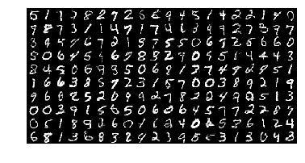

```
Epoch: [40] time: 360.18s, d_loss: 1.2239, g_loss: 0.8377
Epoch: [41] time: 369.31s, d_loss: 1.2128, g_loss: 0.8132
Epoch: [42] time: 378.36s, d_loss: 1.1998, g_loss: 0.8118
Epoch: [43] time: 387.42s, d_loss: 1.2140, g_loss: 0.8476
Epoch: [44] time: 396.47s, d_loss: 1.2416, g_loss: 0.8270
Epoch: [45] time: 405.57s, d_loss: 1.2092, g_loss: 0.8730
Epoch: [46] time: 414.70s, d_loss: 1.2405, g_loss: 0.8731
Epoch: [47] time: 423.80s, d_loss: 1.1805, g_loss: 0.8523
Epoch: [48] time: 432.89s, d_loss: 1.1806, g_loss: 0.8370
Epoch: [49] time: 441.93s, d_loss: 1.1894, g_loss: 0.8510
```

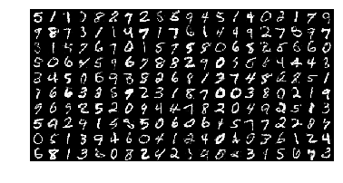

```
Epoch: [50] time: 453.07s, d_loss: 1.1603, g_loss: 0.8754
Epoch: [51] time: 462.16s, d_loss: 1.2282, g_loss: 0.8241
Epoch: [52] time: 471.22s, d_loss: 1.1592, g_loss: 0.8527
Epoch: [53] time: 480.32s, d_loss: 1.1517, g_loss: 0.8843
Epoch: [54] time: 489.35s, d_loss: 1.1616, g_loss: 0.8596
Epoch: [55] time: 498.39s, d_loss: 1.1952, g_loss: 0.8398
Epoch: [56] time: 507.40s, d_loss: 1.2192, g_loss: 0.8194
Epoch: [57] time: 516.48s, d_loss: 1.2193, g_loss: 0.8954
Epoch: [58] time: 525.67s, d_loss: 1.1830, g_loss: 0.8769
Epoch: [59] time: 534.77s, d_loss: 1.1795, g_loss: 0.8728
```

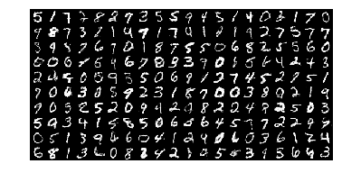

```
Epoch: [60] time: 545.23s, d_loss: 1.2006, g_loss: 0.8720
Epoch: [61] time: 554.40s, d_loss: 1.1985, g_loss: 0.8298
Epoch: [62] time: 563.40s, d_loss: 1.1798, g_loss: 0.8534
Epoch: [63] time: 572.45s, d_loss: 1.1398, g_loss: 0.8617
Epoch: [64] time: 581.61s, d_loss: 1.1845, g_loss: 0.8667
Epoch: [65] time: 590.74s, d_loss: 1.1856, g_loss: 0.8199
Epoch: [66] time: 599.82s, d_loss: 1.1769, g_loss: 0.9124
Epoch: [67] time: 608.90s, d_loss: 1.1062, g_loss: 0.9238
Epoch: [68] time: 618.01s, d_loss: 1.2318, g_loss: 0.9037
Epoch: [69] time: 627.20s, d_loss: 1.1044, g_loss: 0.9099
```

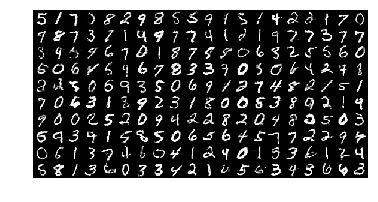

```
Epoch: [70] time: 637.67s, d_loss: 1.1329, g_loss: 0.8956
Epoch: [71] time: 646.81s, d_loss: 1.1343, g_loss: 0.8814
Epoch: [72] time: 655.95s, d_loss: 1.1078, g_loss: 0.9211
Epoch: [73] time: 665.04s, d_loss: 1.1497, g_loss: 0.8845
Epoch: [74] time: 674.13s, d_loss: 1.1481, g_loss: 0.9074
Epoch: [75] time: 683.15s, d_loss: 1.1090, g_loss: 0.8972
Epoch: [76] time: 692.23s, d_loss: 1.1848, g_loss: 0.8555
Epoch: [77] time: 701.33s, d_loss: 1.1457, g_loss: 0.8889
Epoch: [78] time: 710.44s, d_loss: 1.0880, g_loss: 0.9293
Epoch: [79] time: 719.50s, d_loss: 1.1888, g_loss: 0.9185
```

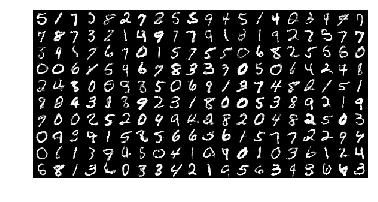

```
Epoch: [80] time: 730.02s, d_loss: 1.0979, g_loss: 0.8996
Epoch: [81] time: 739.10s, d_loss: 1.1923, g_loss: 0.9259
Epoch: [82] time: 748.17s, d_loss: 1.1291, g_loss: 0.9024
Epoch: [83] time: 757.19s, d_loss: 1.1173, g_loss: 0.9094
Epoch: [84] time: 766.19s, d_loss: 1.1077, g_loss: 0.9200
Epoch: [85] time: 775.21s, d_loss: 1.1039, g_loss: 0.9140
Epoch: [86] time: 784.22s, d_loss: 1.1786, g_loss: 0.8745
Epoch: [87] time: 793.26s, d_loss: 1.1135, g_loss: 0.9132
Epoch: [88] time: 802.27s, d_loss: 1.1289, g_loss: 0.9221
Epoch: [89] time: 811.26s, d_loss: 1.0913, g_loss: 0.9613
```

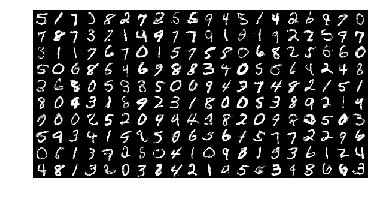

```
Epoch: [90] time: 816.95s, d_loss: 1.0863, g_loss: 0.9795
Epoch: [91] time: 820.71s, d_loss: 1.1462, g_loss: 0.9393
Epoch: [92] time: 824.45s, d_loss: 1.0883, g_loss: 0.8874
Epoch: [93] time: 828.17s, d_loss: 1.1339, g_loss: 0.9482
Epoch: [94] time: 835.03s, d_loss: 1.0812, g_loss: 0.9582
Epoch: [95] time: 844.00s, d_loss: 1.0684, g_loss: 0.9124
Epoch: [96] time: 853.02s, d_loss: 1.1512, g_loss: 0.9223
Epoch: [97] time: 862.03s, d_loss: 1.1311, g_loss: 1.0074
Epoch: [98] time: 871.05s, d_loss: 1.1492, g_loss: 0.9836
Epoch: [99] time: 880.10s, d_loss: 1.1130, g_loss: 0.9344
```

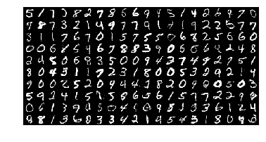

```python
# Start training
dcgan.train()
```

We plot the training loss of discriminator and generator. We can see that we can't tell the model is converged or not from the training loss. Both curves oscillate at certain levels and it's independent with the quality of the generated images. So in practice, we plot the generated samples to monitor the training process. And due to this inconvenience, there are some works proposed in 2017 tried to solved it.

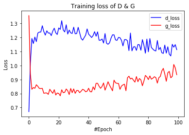

```python
d_loss = dcgan.log['d_loss']
g_loss = dcgan.log['g_loss']
plt.plot(range(len(d_loss)), d_loss, color='blue', label='d_loss')
plt.plot(range(len(g_loss)), g_loss, color='red', label='g_loss')
plt.legend(loc="upper right")
plt.xlabel('#Epoch')
plt.ylabel('Loss')
plt.title('Training loss of D & G')
plt.show()
```

```python
imgs = np.array(dcgan.log['gen_samples'])
make_gif(imgs * 255., 'GAN/dcgan.gif', true_image=True, duration=2)

from IPython.display import Image
Image(url='GAN/dcgan.gif')
```

[figure not shown]

In the following code, we simply demo how to load the pretrained DCGAN model.

Ps. Need to train a DCGAN model first.

```
Extracting MNIST-data/train-images-idx3-ubyte.gz
Extracting MNIST-data/train-labels-idx1-ubyte.gz
Extracting MNIST-data/t10k-images-idx3-ubyte.gz
Extracting MNIST-data/t10k-labels-idx1-ubyte.gz
 [*] Reading checkpoints...
INFO:tensorflow:Restoring parameters from checkpoint/mnist_128/DCGAN.model-43001
 [*] Success to read DCGAN.model-43001
```

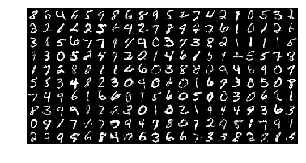

```python
tf.reset_default_graph()
sess.close()

sess = tf.Session()
dcgan = DCGAN(
    sess,
    input_width=28,
    input_height=28,
    output_width=28,
    output_height=28,
    batch_size=128,
    input_fname_pattern='*.jpg',
    checkpoint_dir=checkpoint_dir,
    samples_dir=samples_dir,)

if not dcgan.load(checkpoint_dir)[0]:
  raise Exception("[!] Train a model first, then run test mode")

sample_z = np.random.uniform(-1, 1, size=(200, 100))
samples = dcgan.G.eval(session=dcgan.sess, feed_dict={dcgan.z: sample_z})
# samples = dcgan.trX[:20]
img = grayscale_grid_vis(samples, nhw=(10, 20))
plt.imshow(img, cmap='gray')
plt.axis('off')
plt.show()
```

Clear the tensorflow graph and get ready for the next model.

```python
tf.reset_default_graph()
sess.close()
```

# Wasserstein GAN

There are some theoretical deficiencies in vanilla GAN. Therefore, [Wasserstein GAN (WGAN)](https://arxiv.org/pdf/1701.07875.pdf) was proposed to solve this problem. Apart from the original paper, [this](https://www.cph-ai-lab.com/wasserstein-gan-wgan) and [this](https://www.alexirpan.com/2017/02/22/wasserstein-gan.html) may help you understand the motivation of WGAN. We'll skip the theory in this tutorial and jump directly to the implementation. From the engineering perspective, here are what we need to modify based on DCGAN

- Don't apply sigmoid function to the last layer for the critic
- Don't apply logarithmic function to the generator loss and critic loss
- Training critic multiple iterations per generator iteration
- Using RMSProp as the optimizer, instead of momentum related optimizer like Adam. [Here](http://ruder.io/optimizing-gradient-descent/index.html#rmsprop) is a blog overview of gradient descent optimization algorithm.
- Applying weight clipping in the critic network

Details of the algorithm are shown below.

[figure not shown]

```python
#Inherit from DCGAN class
class WGAN(DCGAN):

  def build_model(self):

    # Training critic 5 iterations per generator iteration
    self.n_critic = 5

    image_dims = [self.input_height, self.input_width, self.c_dim]

    self.inputs = tf.placeholder(
        tf.float32, [None] + image_dims, name='real_images')
    self.sample_inputs = tf.placeholder(
        tf.float32, [None] + image_dims, name='sample_inputs')

    inputs = self.inputs
    sample_inputs = self.sample_inputs

    self.z = tf.placeholder(tf.float32, [None, self.z_dim], name='z')

    self.G = self.generator(self.z)
    self.D, self.D_logits_real = self.discriminator(inputs)

    self.D_, self.D_logits_fake = self.discriminator(self.G, reuse=True)

    self.d_loss_real = tf.reduce_mean(self.D_logits_real)
    self.d_loss_fake = tf.reduce_mean(self.D_logits_fake)
    self.g_loss = -tf.reduce_mean(self.D_logits_fake)
    self.d_loss = self.d_loss_fake - self.d_loss_real

    t_vars = tf.trainable_variables()

    self.d_vars = [var for var in t_vars if 'd_' in var.name]
    self.g_vars = [var for var in t_vars if 'g_' in var.name]
    self.saver = tf.train.Saver()

  def train(self):
    g_optim = tf.train.RMSPropOptimizer(learning_rate=5e-5).minimize(
        self.g_loss, var_list=self.g_vars)
    d_optim = tf.train.RMSPropOptimizer(learning_rate=5e-5).minimize(
        self.d_loss, var_list=self.d_vars)

    #get the weight clipping ops
    clip_ops = []
    for var in self.d_vars:
      clip_bounds = [-.01, .01]
      clip_ops.append(
          tf.assign(var, tf.clip_by_value(var, clip_bounds[0], clip_bounds[1])))
    clip_disc_weights = tf.group(*clip_ops)

    init = tf.global_variables_initializer()
    self.sess.run(init)

    sample_z = np.random.uniform(-1, 1, size=(self.sample_num, self.z_dim))
    sample_idxs = np.random.randint(
        low=0, high=len(self.trX), size=self.sample_num)
    sample_inputs = self.trX[sample_idxs]

    counter = 1
    self.n_critic += 1
    start_time = time.time()
    for epoch in range(self.epoch):
      shuffle(self.trX)
      for batch_images in iter_data(self.trX, size=self.batch_size):
        batch_z = np.random.uniform(-1, 1, [self.batch_size,
                                            self.z_dim]).astype(np.float32)
        if counter % self.n_critic:
          # Update D network
          self.sess.run(
              d_optim, feed_dict={
                  self.inputs: batch_images,
                  self.z: batch_z,
              })
          #Apply weight clipping to D network
          self.sess.run(clip_disc_weights)
        else:
          # Update G network
          self.sess.run(
              g_optim, feed_dict={
                  self.z: batch_z,
              })
        counter += 1

      errD_fake = self.d_loss_fake.eval(
          session=self.sess, feed_dict={self.z: batch_z})
      errD_real = self.d_loss_real.eval(
          session=self.sess, feed_dict={self.inputs: batch_images})
      errG = self.g_loss.eval(session=self.sess, feed_dict={self.z: batch_z})
      self.log['d_loss'].append(errD_fake + errD_real)
      self.log['g_loss'].append(errG)
      print("Epoch: [%2d] time: %.2fs, d_loss: %.4f, g_loss: %.4f" \
        % (epoch,time.time() - start_time, errD_fake+errD_real, errG))

      if (epoch + 1) % 1 == 0:
        samples = self.sess.run(
            self.G, feed_dict={
                self.z: sample_z,
            })
        img = grayscale_grid_vis(
            samples,
            nhw=(10, 20),
            save_path=self.samples_dir + '/%d.jpg' % epoch)
        self.log['gen_samples'].append(img)
        if (epoch + 1) % 10 == 0:
          if self.show_samples:
            plt.imshow(img, cmap='gray')
            plt.axis('off')
            plt.show()

      if (epoch + 1) % 10 == 0:
        self.save(self.checkpoint_dir, counter)
```